# Multi-omics Data Analysis Workshop: Day 2

Paul Stewart

# Introduction

Yesterday we worked with a single omics table. Today we will work with two tables from the same samples, one with gene expression and one with targeted lipid abundance. We will use many of the same R functions, including `head()`, `subset()`, `plot()`, and `prcomp()`.

We will work through two questions:

1. Which genes show similar expression patterns, and how do they relate to lipids?
2. Can we combine two types of omics data to identify a single set of sample clusters?

For the first question, we will perform horizontal integration with gene expression and lipid data. We will use Weighted Gene Co-expression Network Analysis (WGCNA) to find groups of genes that behave similarly, then relate those groups to individual fatty acids. Langfelder and Horvath provide R scripts, example data, and tutorials at https://edo98811.github.io/WGCNA_official_documentation/. Their paper is at https://doi.org/10.1186/1471-2105-9-559.

For the second question, we will perform vertical integration with the same two datasets. We will use Similarity Network Fusion (SNF) to combine information from the gene and lipid measurements, cluster the mice, and look at what differs between clusters. The SNF paper is at https://doi.org/10.1038/nmeth.2810. The SNFtool manual has a worked example at https://cran.r-project.org/web/packages/SNFtool/SNFtool.pdf.

## Set up R

The setup chunk above uses `here()` as we did on Day 1, so we should be ready to go.

The following installation chunk has eval = FALSE so packages are not installed each time we knit (render the document into a html or pdf document), but if you followed the introductory email then you should already have these installed. If you do not, please run this chunk now and get the required packages installed.

```r
options(repos = c(CRAN = "https://cloud.r-project.org"))
install.packages(c("rmarkdown", "knitr", "here", "circlize", "SNFtool", "enrichR", "BiocManager"))
BiocManager::install(c("mixOmics", "WGCNA", "ComplexHeatmap"), ask = FALSE, update = FALSE)
```

```r
library(WGCNA)
library(ComplexHeatmap)
library(circlize)
library(SNFtool)
library(grid)

# This option tells WGCNA to use one thread for its calculations.
# Multiple threads can split up the work, but this dataset is small.
disableWGCNAThreads()
```

# Read in and view data

## Today’s experiment

We will work with the Nutrimouse dataset from Martin and colleagues’ study in Hepatology. https://doi.org/10.1002/hep.21510. The study asked how dietary fats affect the liver in wild-type and PPAR-alpha-deficient mice. 40 mice received one of five diets based on different oils (reference, coconut, fish, linseed, or sunflower). The gene table has 120 measurements from a targeted expression array, and the lipid table has 21 fatty acids measured by gas chromatography.

Nutrimouse comes with the mixOmics package, so there is no external file to open with `read.delim()`. We can load example datasets that come with R packages using `data()`.

```r
data("nutrimouse", package = "mixOmics")
```

Let us take a look at the data like we did yesterday. Note that nutrimouse is a list, an R object that can contain multiple objects.

```r
table(nutrimouse$genotype, nutrimouse$diet)
```

```
##
##        coc fish lin ref sun
##   wt     4    4   4   4   4
##   ppar   4    4   4   4   4
```

```r
names(nutrimouse)
```

```
## [1] "gene"     "lipid"    "diet"     "genotype"
```

```r
dim(nutrimouse$gene)
```

```
## [1]  40 120
```

```r
nutrimouse$gene[1:5, 1:5]
```

```
##   X36b4 ACAT1 ACAT2  ACBP  ACC1
## 1 -0.42 -0.65 -0.84 -0.34 -1.29
## 2 -0.44 -0.68 -0.91 -0.32 -1.23
## 3 -0.48 -0.74 -1.10 -0.46 -1.30
## 4 -0.45 -0.69 -0.65 -0.41 -1.26
## 5 -0.42 -0.71 -0.54 -0.38 -1.21
```

The gene table uses the labels that came with Nutrimouse, so you will see names like `ACAT1`. Official mouse gene symbols usually start with a capital letter followed by lowercase letters. Time permitting, we can practice looking up mouse gene identifiers at the end. Mouse Genome Informatics naming guidelines https://www.informatics.jax.org/mgihome/nomen/2021_gene.shtml#ns2.3.1.

```r
dim(nutrimouse$lipid)
```

```
## [1] 40 21
```

```r
nutrimouse$lipid[1:5, 1:5]
```

```
##   C14.0 C16.0 C18.0 C16.1n.9 C16.1n.7
## 1  0.34 26.45 10.22     0.35     3.10
## 2  0.38 24.04  9.93     0.55     2.54
## 3  0.36 23.70  8.96     0.55     2.65
## 4  0.22 25.48  8.14     0.49     2.82
## 5  0.37 24.80  9.63     0.46     2.85
```

`rowSums()` adds up the 21 fatty-acid percentages for each mouse. Use `range()` to see the smallest and largest totals.

```r
range(rowSums(nutrimouse$lipid))
```

```
## [1]  99.97 100.02
```

The totals are close to 100 because the values are percentages.

```r
colnames(nutrimouse$lipid)
```

```
##  [1] "C14.0"    "C16.0"    "C18.0"    "C16.1n.9" "C16.1n.7" "C18.1n.9"
##  [7] "C18.1n.7" "C20.1n.9" "C20.3n.9" "C18.2n.6" "C18.3n.6" "C20.2n.6"
## [13] "C20.3n.6" "C20.4n.6" "C22.4n.6" "C22.5n.6" "C18.3n.3" "C20.3n.3"
## [19] "C20.5n.3" "C22.5n.3" "C22.6n.3"
```

The lipid names indicate the number of carbons, number of double bonds, and the position of the first double bond counting from the methyl end (n-3, n-6, or n-9). For example, C18.2n.6 has 18 carbons, 2 double bonds, and belongs to the omega-6 family.

Take another look at the row and column names. Each row is a mouse, and each column is a gene or fatty acid. We will keep this arrangement because PCA, WGCNA, and SNF all use samples in rows. Let us give the two tables their own names so they are easier to work with.

```r
gene_samples = nutrimouse$gene
lipid_samples = nutrimouse$lipid
dim(gene_samples)
```

```
## [1]  40 120
```

```r
dim(lipid_samples)
```

```
## [1] 40 21
```

Both tables have 40 rows for the same 40 mice. The gene table has 120 columns and the lipid table has 21 columns.

## Make the metadata table

Nutrimouse gives the two assays in matched order, so row `1` in the gene table and row `1` in the lipid table refer to the same mouse. Let us use slightly more verbose sample names. Remember, names and descriptive comments will make your analyses really easy to follow for other people or when you come back to review months or years later. We will use `Mouse_1` for that `1` mouse in both assays and in the metadata and so on.

```r
meta = data.frame(
  sample_id = paste0("Mouse_", rownames(nutrimouse$gene)),
  genotype = as.character(nutrimouse$genotype),
  diet = as.character(nutrimouse$diet)
)
head(meta)
```

```
##   sample_id genotype diet
## 1   Mouse_1       wt  lin
## 2   Mouse_2       wt  sun
## 3   Mouse_3       wt  sun
## 4   Mouse_4       wt fish
## 5   Mouse_5       wt  ref
## 6   Mouse_6       wt  coc
```

```r
# Build the names from the sample numbers in each assay.
rownames(gene_samples) = paste0("Mouse_", rownames(gene_samples))
rownames(lipid_samples) = paste0("Mouse_", rownames(lipid_samples))
head(rownames(gene_samples))
```

```
## [1] "Mouse_1" "Mouse_2" "Mouse_3" "Mouse_4" "Mouse_5" "Mouse_6"
```

```r
head(rownames(lipid_samples))
```

```
## [1] "Mouse_1" "Mouse_2" "Mouse_3" "Mouse_4" "Mouse_5" "Mouse_6"
```

# Match the samples

First use `%in%` to ask if every ID in the metadata is present as a row in each table.

```r
all(meta$sample_id %in% rownames(gene_samples))
```

```
## [1] TRUE
```

```r
all(meta$sample_id %in% rownames(lipid_samples))
```

```
## [1] TRUE
```

Now compare the names one position at a time with `==`. `all()` gives us one `TRUE` if every comparison is true. We have 40 rows in both tables and 40 rows in the metadata, so we can compare their names in order.

```r
all(meta$sample_id == rownames(gene_samples))
```

```
## [1] TRUE
```

```r
all(meta$sample_id == rownames(lipid_samples))
```

```
## [1] TRUE
```

Both checks return `TRUE`, and since the rows already match the metadata order, we can use `gene_samples` and `lipid_samples` as they are. If we were using data where all the IDs are present but the order check returned `FALSE`, then we would use the metadata IDs to reorder the rows. For example, `lipid_samples[meta$sample_id, ]` selects the lipid rows in the order found in the metadata.

# Check each dataset

Check missing values:

```r
sum(is.na(gene_samples))
```

```
## [1] 0
```

```r
sum(is.na(lipid_samples))
```

```
## [1] 0
```

Both datasets are complete, so we are ready to look at the samples with PCA.

Today we will use the gene expression values and fatty-acid percentages as supplied. Each lipid value is that fatty acid’s share of the measured total for one mouse. The table includes some values reported as zero, and we will keep them as zero.

```r
genotype_colors = c(wt = "darkorange2", ppar = "dodgerblue3")
genotype_labels = c("WT", "PPAR-alpha deficient")
meta$color = genotype_colors[meta$genotype]

# Use a different point shape for each diet.
diet_shapes = c(ref = 16, coc = 17, fish = 15, lin = 18, sun = 8)
diet_labels = c("Reference", "Coconut", "Fish oil", "Linseed", "Sunflower")
sample_diet_shapes = diet_shapes[meta$diet]
```

## Review PCA

Recall that PCA summarizes variation across many features using a few new axes. We will center and scale each feature, just as we did yesterday. This gives the features comparable starting scales. `prcomp()` returns each component’s standard deviation in `$sdev`. We square those values to get variances, divide each by the total variance, and multiply by 100 to get the percent variance explained. We do this separately for genes and lipids.

Each point is one mouse. Orange and blue show genotype, and the shape shows diet in both plots. We will use `par()` to put the plots side by side. First, `plot_settings = par("mfrow")` saves the current number of plot rows and columns. Then `par(mfrow = c(1, 2))` changes the layout to one row and two columns. After drawing both plots, `par(mfrow = plot_settings)` restores the layout we saved, so later figures do not keep using two panels.

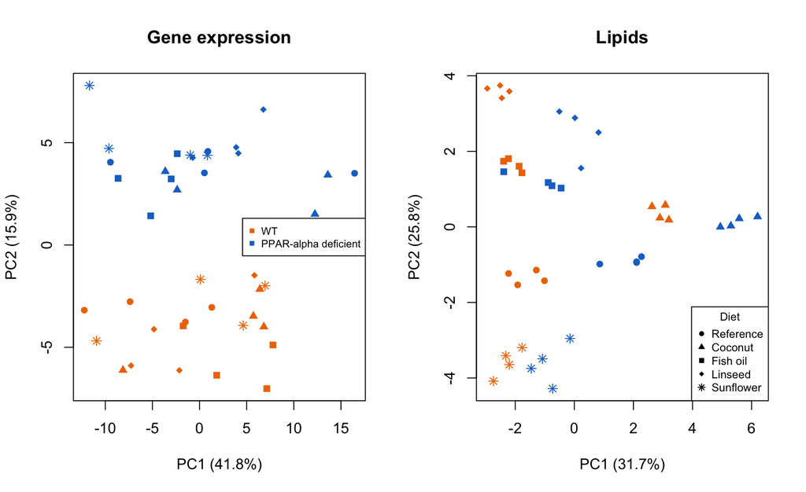

```r
gene_pca = prcomp(gene_samples, center = TRUE, scale. = TRUE)
lipid_pca = prcomp(lipid_samples, center = TRUE, scale. = TRUE)

gene_pc_variance = gene_pca$sdev^2
lipid_pc_variance = lipid_pca$sdev^2
gene_pct_variance = 100 * gene_pc_variance / sum(gene_pc_variance)
lipid_pct_variance = 100 * lipid_pc_variance / sum(lipid_pc_variance)

# Save the current layout before changing the number of plot panels.
plot_settings = par("mfrow")
par(mfrow = c(1, 2))
plot(gene_pca$x[, 1], gene_pca$x[, 2], col = meta$color, pch = sample_diet_shapes,
     xlab = paste0("PC1 (", round(gene_pct_variance[1], 1), "%)"),
     ylab = paste0("PC2 (", round(gene_pct_variance[2], 1), "%)"),
     main = "Gene expression")
legend("right", legend = genotype_labels,
       col = genotype_colors, pch = 15, cex = 0.7)

plot(lipid_pca$x[, 1], lipid_pca$x[, 2], col = meta$color, pch = sample_diet_shapes,
     xlab = paste0("PC1 (", round(lipid_pct_variance[1], 1), "%)"),
     ylab = paste0("PC2 (", round(lipid_pct_variance[2], 1), "%)"),
     main = "Lipids")
legend("bottomright", title = "Diet", legend = diet_labels,
       pch = diet_shapes, cex = 0.75)
```

```r
# Restore the layout we saved before making these plots.
par(mfrow = plot_settings)
```

### Questions

`sample()` picks values at random from a vector. Use `size = 1` to pick one value. Try running this a few times.

```r
sample(c("cat", "dog", "fish"), size = 1)
```

```
## [1] "cat"
```

1. Make a copy of `meta` called `practice_meta`. Pick a random row number to change with `row_to_change = sample(1:nrow(practice_meta), size = 1)` and set `practice_meta$sample_id[row_to_change] = "Mouse_99"`. Check the practice IDs against `rownames(lipid_samples)` with `%in%`. Which row comes back `FALSE`? Check it against `row_to_change`.
2. Reverse the lipid rows with `lipid_reversed = lipid_samples[rev(rownames(lipid_samples)), ]`. Use `%in%` and `all()` to check that all the metadata IDs are present. Now use `all(a == b)`, replacing `a` with the metadata IDs and `b` with the reversed row names. Which check returns `TRUE`? What does this tell you about how to check for matching samples? Use the metadata to put the rows back in order and run both checks again.
3. Use `subset()` to make metadata for just the wild-type mice. Use its `sample_id` column to select those rows from `gene_samples`.
4. What is the most noticeable pattern in each PCA? Are the patterns consistent across the two assays?
5. Choose one PCA and add the percentages on PC1 and PC2. How much of that dataset’s variation is shown in the plot, and how much is left in the other components? Does the amount shown tell us which genotype or diet forms a group, or do we need to look at the points and labels too?
6. Use `subset()` to get the IDs of mice on the coconut diet (`coc`). Use these IDs to select rows from `lipid_pca$x` and plot PC1 against PC2. How many mice did you plot? Find the same points in the full lipid PCA.

# Horizontal integration with WGCNA

## Group genes that behave similarly

WGCNA (Weighted Gene Co-expression Network Analysis) identifies groups of genes with similar expression patterns across samples. It starts by calculating correlations between genes and uses these to build a network of gene connections. It then groups genes into modules based on how strongly they are connected to one another and how many connections they share with other genes.

One advantage of WGCNA is that it identifies modules directly from the expression data rather than relying on predefined pathways. This means we can discover groups of genes that may not be captured by existing pathway databases. Once we have identified our modules, we can use pathway enrichment to understand their biological functions. We can also compare the modules with our lipid measurements to see how gene expression and lipid levels are related.

Before we start, let’s use WGCNA’s goodSamplesGenes() function to check our data. It looks for genes or mice with too many missing measurements and genes with essentially no variation across samples. The allOK result should be TRUE, indicating that our data pass these checks.

```r
gene_check = goodSamplesGenes(gene_samples, verbose = 0)
gene_check$allOK
```

```
## [1] TRUE
```

## Look at the gene correlations

Let’s start by comparing the first two genes in our table. We have 40 expression measurements for each gene, one from each mouse. We want to know if the two genes have similar expression patterns across mice. We can use cor() to calculate their correlation. A value near +1 means that when one gene has higher expression, the other tends to have higher expression too. A value near −1 means they tend to show opposite patterns, while a value near zero means there is little linear relationship.

We could repeat this for every pair of genes, but cor() can do that for us when we give it the whole table. Since genes are in columns, it compares every gene with every other gene and returns a correlation matrix. Run the first line below to calculate the correlation between our first two genes, then find that same value in row 1, column 2 of gene_cor.

```r
cor(gene_samples[, 1], gene_samples[, 2])
```

```
##           [,1]
## [1,] 0.3275417
```

```r
gene_cor = cor(gene_samples)
dim(gene_cor)
```

```
## [1] 120 120
```

```r
round(gene_cor[1:5, 1:5], 2)
```

```
##       X36b4 ACAT1 ACAT2  ACBP  ACC1
## X36b4  1.00  0.33  0.11  0.26  0.49
## ACAT1  0.33  1.00 -0.12 -0.03  0.52
## ACAT2  0.11 -0.12  1.00  0.33 -0.15
## ACBP   0.26 -0.03  0.33  1.00  0.30
## ACC1   0.49  0.52 -0.15  0.30  1.00
```

Now we have a 120 by 120 table of correlations. Each row and column names a gene, and each square tells us how that pair behaves across the mice. The diagonal contains ones because each gene is being compared with itself. You will also see the same values above and below the diagonal because comparing gene A with gene B gives the same correlation as comparing B with A.

We can represent gene correlations as a network, where each gene is a node, and the connections between genes (edges) are based on their correlations. But if we do this, each of our 120 genes could connect to the other 119 genes. Multiplying 120 by 119 counts every pair twice, once as A–B and once as B–A, so we divide by two: 120 * 119 / 2 = 7,140 possible connections. That is a lot of connections to consider in our network! WGCNA addresses this by raising the correlation-based similarities to a power, which reduces the influence of weaker connections and emphasizes genes with stronger shared patterns.

For this analysis, we are interested in genes with strong positive correlations, meaning genes whose expression levels increase and decrease together across samples. We use the “signed” option in WGCNA to give these genes stronger connections while reducing the influence of negative correlations. First, WGCNA uses (1 + r) / 2, where r is the correlation, to convert correlations into values between 0 and 1. For example, a correlation of +0.9 becomes 0.95, while −0.9 becomes 0.05.

Next we raise those connection values to a power. Values between 0 and 1 get smaller when we raise them to a power, and smaller starting values drop toward zero faster. For example, at power 20, a connection value of 0.80 becomes about 0.01 and a value of 0.95 becomes about 0.36. This is called soft thresholding because each pair keeps a weight that describes its connection strength. The result is a weighted network, where connections can have different strengths rather than simply being present or absent.

Hard thresholding makes a yes-or-no decision. For example, we could give a pair a connection of 1 if its correlation is at least 0.8 and a connection of 0 otherwise. Correlations of 0.79 and 0.81 would then give very different results. Soft thresholding changes the weights smoothly as the correlations change.

## Choose a soft-thresholding power

We have seen how raising our connection strengths to a power reduces the influence of weaker correlations. But how do we decide which power to use? A lower power leaves more genes strongly connected, while a higher power makes more connections very weak. WGCNA has a function called pickSoftThreshold() that tries several powers and helps us choose an appropriate value.

To understand how this works, we first need to introduce connectivity. In a simple network, connectivity is the number of connections a gene has to other genes. In our weighted network, connections have different strengths, so we add up those strengths to calculate connectivity. For example, if a gene has five connections, each with a strength of 0.2, its connectivity is 1. We do not count a gene’s connection to itself. Genes with high connectivity are strongly connected to many other genes and are often called hub genes.

Why does connectivity matter when choosing a power? One assumption used by WGCNA is that biological networks tend to have many genes with low connectivity and a relatively small number of highly connected hub genes. This is called scale-free topology. It is a useful model for network construction, although real biological networks do not necessarily follow it perfectly.

The pickSoftThreshold() function evaluates how closely the network follows this pattern at each power. It gives us a scale-free topology fit score (R-squared), where higher values indicate a better fit. In the WGCNA tutorial, a score of 0.90 is used as a target, so we will look for the first power that reaches this value.

However, we also need to consider mean connectivity, which tells us how strongly connected the genes are on average. If we choose a power that is too high, most connections may become extremely weak. We therefore want a power that gives us a reasonably good scale-free fit without making the network too sparse.

We will use two plots to help make this decision: scale-free topology fit versus power and mean connectivity versus power. If no power reaches our target fit, we can use both plots to choose a reasonable compromise.

You can find a more detailed explanation of this procedure in the official WGCNA tutorial https://edo98811.github.io/WGCNA_official_documentation/FemaleLiver-02-networkConstr-man.pdf.

```r
candidate_powers = c(1:10, seq(12, 30, by = 2))
fit_cutoff = 0.90
power_check = pickSoftThreshold(gene_samples, powerVector = candidate_powers,
                                RsquaredCut = fit_cutoff, networkType = "signed",
                                verbose = 0)
```

In addition to calculating the fit scores for each power, pickSoftThreshold() tries to recommend a power automatically based on our target fit of 0.90. Let’s see what it recommends.

```r
power_check$powerEstimate
```

```
## [1] NA
```

We get NA, meaning none of the powers we tested reached our target of 0.90. That does not mean we cannot choose a power ourselves. Let’s look at the two diagnostic plots to see which power might be a reasonable choice.

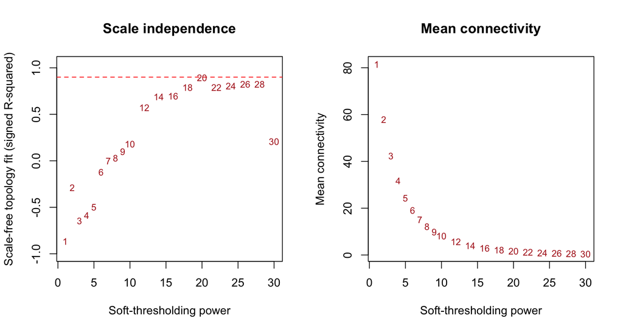

```r
power_results = power_check$fitIndices[, c("Power", "SFT.R.sq", "slope", "mean.k.")]
# Give a positive score only when highly connected genes are less common.
signed_fit = -sign(power_results$slope) * power_results$SFT.R.sq

# Save the current layout before changing the number of plot panels.
plot_settings = par("mfrow")
par(mfrow = c(1, 2))
plot(power_results$Power, signed_fit, type = "n", ylim = c(-1, 1.04),
     xlab = "Soft-thresholding power", ylab = "Scale-free topology fit (signed R-squared)",
     main = "Scale independence")
abline(h = fit_cutoff, col = "red", lty = 2)
text(power_results$Power, signed_fit, labels = power_results$Power, col = "firebrick", cex = 0.8)

plot(power_results$Power, power_results$mean.k., type = "n",
     xlab = "Soft-thresholding power", ylab = "Mean connectivity",
     main = "Mean connectivity")
text(power_results$Power, power_results$mean.k., labels = power_results$Power,
     col = "firebrick", cex = 0.8)
```

```r
# Restore the layout we saved before making these plots.
par(mfrow = plot_settings)
```

Now let’s look at the results from pickSoftThreshold(). Remember, we want to choose a power that gives us a network with a reasonable scale-free pattern, without making all the connections between genes too weak. The plot on the left shows the scale-free topology fit. Each number represents a different power, and the y-axis shows how closely the resulting network follows the scale-free pattern. Ideally, we want a high, positive fit score that reaches the red line at 0.90. None of the powers quite reaches this threshold, but power 20 comes closest, with a fit of about 0.895. Notice that power 1 has a negative score. This means the relationship between connectivity and its frequency goes in the opposite direction from what we expect for a scale-free network, so we would not choose it despite its high R-squared.

The plot on the right shows mean connectivity, or the average sum of connection strengths across all 120 genes. As we increase the power, connections become weaker, so mean connectivity decreases. For example, at power 12, mean connectivity is about 5.66, but by power 20 it has dropped to 1.69. Remember, these values represent the sum of connection strengths, not the number of connections. Why does this matter? If we choose a power that is too high, we risk making nearly all the connections very weak. We want a good scale-free fit, but we also want to preserve meaningful connections between genes.

Looking at both plots together, we will use power 20 for this exercise. It gives us the best scale-free fit among the powers tested, although mean connectivity is relatively low. You may also notice that pickSoftThreshold() returns NA for its automatic power estimate because none of the powers reaches our target of 0.90. Interestingly, using the function’s default threshold of 0.85 would select power 1, even though its fit has the wrong direction. This is why we examine both plots rather than relying entirely on the automatic estimate. There is no universally optimal power, and the choice depends on the characteristics of the dataset.

```r
soft_power = 20
```

### See what signing and the power do to gene connections

Now that we have chosen power 20, let’s see what happens to our gene correlations. The plot on the left shows the original correlations between genes, ranging from −1 to +1. The plot on the right shows the connection strengths after applying the signed transformation (1 + r) / 2 and raising the results to power 20. Both plots show the same genes in the same order, so we can compare them directly.

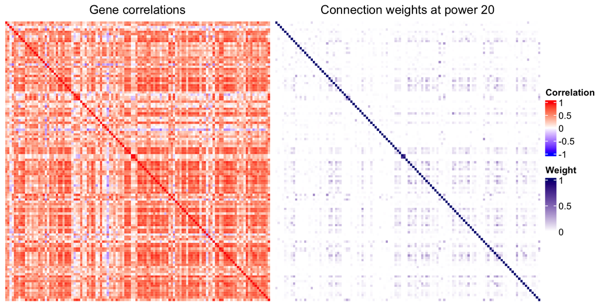

```r
gene_connection_weights = ((1 + gene_cor) / 2)^soft_power
cor_colors = colorRamp2(c(-1, 0, 1), c("blue", "white", "red"))
weight_colors = colorRamp2(c(0, 1), c("white", "navy"))

Heatmap(gene_cor, name = "Correlation", col = cor_colors,
        column_title = "Gene correlations",
        cluster_rows = FALSE, cluster_columns = FALSE,
        show_row_names = FALSE, show_column_names = FALSE) +
  Heatmap(gene_connection_weights, name = "Weight", col = weight_colors,
          column_title = paste("Connection weights at power", soft_power),
          cluster_rows = FALSE, cluster_columns = FALSE,
          show_row_names = FALSE, show_column_names = FALSE)
```

Notice how many of the connections become much weaker in the right-hand plot. Strong positive correlations retain relatively higher connection strengths, while negative and weaker positive correlations are pushed toward zero. This is exactly what we wanted: a network that emphasizes genes with strong positive correlations rather than treating all correlations equally.

## Find the modules

Now that we have chosen our power and constructed our network, we want to identify modules, or groups of genes that have similar expression patterns. WGCNA has a function called blockwiseModules() that handles this process for us. We give it our original gene_samples table, with mice in rows and genes in columns, along with the power and network settings we chose earlier. The function then builds the network and identifies the modules.

How does WGCNA decide which genes belong together? Rather than looking only at the correlation between two genes, it also considers how strongly they connect to the same other genes. Think of it this way: if two genes are both strongly connected to many of the same genes, that suggests they may belong to the same module. WGCNA measures this using something called topological overlap (TOM). It then uses hierarchical clustering to group genes based on their topological overlap. We have used hierarchical clustering before, but this time we are clustering genes based on their shared network connections rather than their original expression values. WGCNA identifies modules from the branches of the resulting clustering tree and can merge modules that have similar overall expression patterns.

The code below uses blockwiseModules() to perform all these steps. Most of the settings can be left at their defaults, but we will specify a few:

- `power = soft_power` uses the power we selected earlier (20) to calculate the connection strengths.
- `networkType = "signed"` gives stronger connections to positively correlated genes, as we discussed above.
- `TOMType = "signed"` tells WGCNA how to calculate topological overlap using the network connections. This is the default setting.
- `minModuleSize = 10` sets the minimum number of genes in a module to 10, rather than the default of 20. We are using a smaller value because our dataset contains only 120 genes.
- `mergeCutHeight = 0.25` controls how similar modules need to be before WGCNA merges them. Increasing this value from the default of 0.15 makes merging more likely.

`randomSeed = workshop_seed` makes the results reproducible, nThreads = 1 limits the calculation to one processing thread, and verbose = 0 reduces the amount of output printed to the Console.

```r
gene_network = blockwiseModules(
  gene_samples,
  power = soft_power,
  networkType = "signed",
  TOMType = "signed",
  minModuleSize = 10,
  mergeCutHeight = 0.25,
  randomSeed = workshop_seed,
  nThreads = 1,
  verbose = 0
)
```

The resulting `gene_network` is a list, like `nutrimouse`. Use `names()` to see what WGCNA returned. We will use `$colors` for the module labels and `$MEs` for the module summaries.

```r
names(gene_network)
```

```
##  [1] "colors"         "unmergedColors" "MEs"            "goodSamples"
##  [5] "goodGenes"      "dendrograms"    "TOMFiles"       "blockGenes"
##  [9] "blocks"         "MEsOK"
```

## Which genes are in each module?

WGCNA uses color names because the groups are defined by the expression data. Here we have three modules, blue, brown, and turquoise. Grey collects the genes that were left unassigned.

```r
module_membership = data.frame(
  gene = colnames(gene_samples),
  module = gene_network$colors
)
table(module_membership$module)
```

```
##
##      blue     brown      grey turquoise
##        27        10        11        72
```

```r
head(module_membership)
```

```
##        gene    module
## X36b4 X36b4 turquoise
## ACAT1 ACAT1 turquoise
## ACAT2 ACAT2      grey
## ACBP   ACBP      blue
## ACC1   ACC1 turquoise
## ACC2   ACC2     brown
```

We can use subset() to look at the genes in one module. Let us start with the blue module.

```r
blue_genes = subset(module_membership, module == "blue")
blue_genes
```

```
##              gene module
## ACBP         ACBP   blue
## ALDH3       ALDH3   blue
## AOX           AOX   blue
## BACT         BACT   blue
## BIEN         BIEN   blue
## BSEP         BSEP   blue
## CACP         CACP   blue
## CBS           CBS   blue
## CPT2         CPT2   blue
## CYP27a1   CYP27a1   blue
## CYP3A11   CYP3A11   blue
## CYP4A10   CYP4A10   blue
## CYP4A14   CYP4A14   blue
## GSTa         GSTa   blue
## GSTmu       GSTmu   blue
## HPNCL       HPNCL   blue
## L.FABP     L.FABP   blue
## Lpin2       Lpin2   blue
## MRP6         MRP6   blue
## PECI         PECI   blue
## PMDCI       PMDCI   blue
## THIOL       THIOL   blue
## Tpalpha   Tpalpha   blue
## Tpbeta     Tpbeta   blue
## apoE         apoE   blue
## cMOAT       cMOAT   blue
## mHMGCoAS mHMGCoAS   blue
```

## Summarize each module

WGCNA runs principal component analysis on the expression of the genes in each module. It takes the first principal component, PC1, as a representative measure of what those genes are doing together. This is called the module eigengene (many gene signatures work in a similar way by combining expression from several genes into one score). We have one eigengene for each of our three modules and one value for each mouse in each eigengene.

```r
module_eigengenes = gene_network$MEs

# Leave out grey because those genes were not assigned to a module.
module_eigengenes = module_eigengenes[, colnames(module_eigengenes) != "MEgrey", drop = FALSE]
dim(module_eigengenes)
```

```
## [1] 40  3
```

```r
head(module_eigengenes)
```

```
##          MEturquoise     MEblue     MEbrown
## Mouse_1 -0.087287228 0.17090743 -0.07355857
## Mouse_2  0.073751458 0.17468838  0.07740323
## Mouse_3 -0.290351017 0.02288331 -0.01336864
## Mouse_4 -0.058003694 0.14597629 -0.14368823
## Mouse_5  0.001884336 0.01810666  0.21118678
## Mouse_6  0.085084183 0.12862475  0.30607487
```

```r
# Check that these rows still follow the metadata before using its group labels.
all(rownames(module_eigengenes) == meta$sample_id)
```

```
## [1] TRUE
```

```r
table(meta$genotype)
```

```
##
## ppar   wt
##   20   20
```

The number of modules can vary with the number of genes and the WGCNA settings. Here we have 40 rows, one per mouse, and a column for each of the three modules. Since the eigengene gives us one score per mouse for the whole module, we can ask if that score tends to be higher in WT or PPAR-alpha-deficient mice. Use the genotype in `meta` to split the scores into two groups, then make a boxplot for each module.

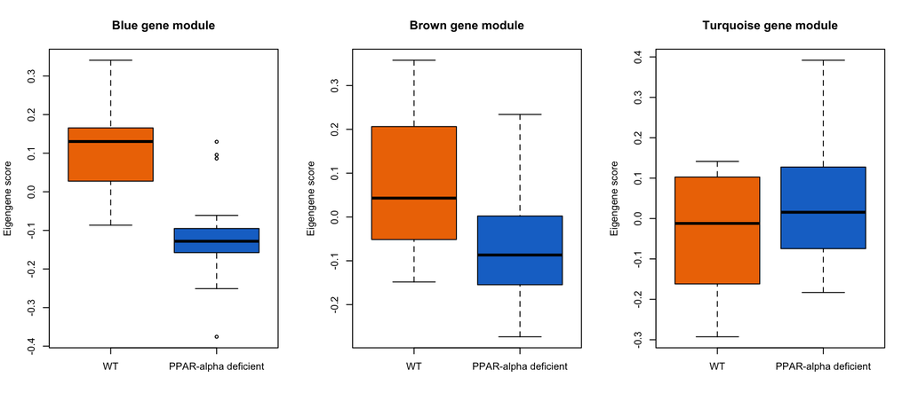

```r
wt_samples = subset(meta, genotype == "wt")$sample_id
ppar_samples = subset(meta, genotype == "ppar")$sample_id

blue_wt = module_eigengenes[wt_samples, "MEblue"]
blue_ppar = module_eigengenes[ppar_samples, "MEblue"]
brown_wt = module_eigengenes[wt_samples, "MEbrown"]
brown_ppar = module_eigengenes[ppar_samples, "MEbrown"]
turquoise_wt = module_eigengenes[wt_samples, "MEturquoise"]
turquoise_ppar = module_eigengenes[ppar_samples, "MEturquoise"]

# Save the current layout before changing the number of plot panels.
plot_settings = par("mfrow")
par(mfrow = c(1, 3))
boxplot(blue_wt, blue_ppar, names = genotype_labels,
        col = genotype_colors, ylab = "Eigengene score",
        main = "Blue gene module")
boxplot(brown_wt, brown_ppar, names = genotype_labels,
        col = genotype_colors, ylab = "Eigengene score",
        main = "Brown gene module")
boxplot(turquoise_wt, turquoise_ppar, names = genotype_labels,
        col = genotype_colors, ylab = "Eigengene score",
        main = "Turquoise gene module")
```

```r
# Restore the layout we saved before making these plots.
par(mfrow = plot_settings)
```

These boxplots let us see if the overall expression patterns of our gene modules differ between WT and PPAR-alpha-deficient mice. A higher eigengene score does not necessarily mean that all genes in the module have higher expression. To understand what these differences mean biologically, we would need to examine the genes in each module and their functions.

## Test the blue eigengene between genotypes

Let us use the same Welch t-test as on Day 1 to test if the blue eigengene differs between WT and PPAR-alpha-deficient mice.

```r
t.test(blue_wt, blue_ppar)
```

```
##
##  Welch Two Sample t-test
##
## data:  blue_wt and blue_ppar
## t = 6.4954, df = 37.75, p-value = 1.229e-07
## alternative hypothesis: true difference in means is not equal to 0
## 95 percent confidence interval:
##  0.1578701 0.3008779
## sample estimates:
## mean of x mean of y
##  0.114687 -0.114687
```

## Look at the genes inside the modules

The eigengene summarizes each module with one score per mouse, but what do the individual genes look like? Let’s make a heatmap of their expression, keeping genes grouped by their WGCNA modules and clustering them within each module based on their expression patterns.

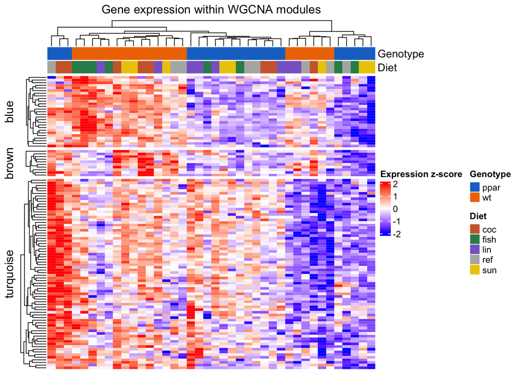

```r
module_genes = subset(module_membership, module != "grey")
module_expression = gene_samples[, module_genes$gene]

# Scale each gene across mice, then put genes in rows for the heatmap.
module_heatmap = t(scale(module_expression))
diet_colors = c(ref = "grey70", coc = "sienna3", fish = "seagreen4",
                lin = "mediumpurple3", sun = "gold2")
module_annotation = HeatmapAnnotation(
  Genotype = meta$genotype,
  Diet = meta$diet,
  col = list(Genotype = genotype_colors, Diet = diet_colors)
)

Heatmap(
  module_heatmap,
  name = "Expression z-score",
  col = colorRamp2(c(-2, 0, 2), c("blue", "white", "red")),
  top_annotation = module_annotation,
  row_split = module_genes$module,
  cluster_rows = TRUE,
  cluster_row_slices = FALSE,
  cluster_columns = TRUE,
  show_row_names = FALSE,
  show_column_names = FALSE,
  column_title = "Gene expression within WGCNA modules"
)
```

# Integrate gene modules with lipids

## Start with one scatter plot

Let’s start with the blue gene module and one lipid, C16.0 (palmitic acid). We will put their values side by side in a data frame, with one row per mouse, to make them easier to plot.

```r
all(rownames(module_eigengenes) == rownames(lipid_samples))
```

```
## [1] TRUE
```

```r
eigengene_lipid = data.frame(
  sample_id = rownames(module_eigengenes),
  blue_eigengene = module_eigengenes$MEblue,
  palmitic_acid = lipid_samples[, "C16.0"]
)
head(eigengene_lipid, 3)
```

```
##   sample_id blue_eigengene palmitic_acid
## 1   Mouse_1     0.17090743         26.45
## 2   Mouse_2     0.17468838         24.04
## 3   Mouse_3     0.02288331         23.70
```

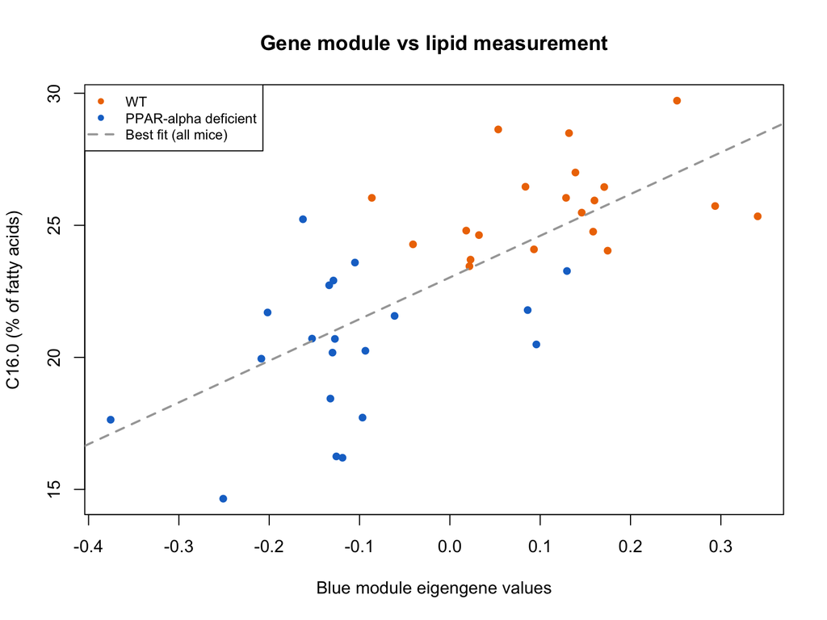

```r
plot(eigengene_lipid$blue_eigengene, eigengene_lipid$palmitic_acid,
     col = meta$color, pch = 16,
     xlab = "Blue module eigengene values",
     ylab = "C16.0 (% of fatty acids)",
     main = "Gene module vs lipid measurement")

# Fit one straight line using all 40 mice and add it to the plot.
module_lipid_fit = lm(palmitic_acid ~ blue_eigengene, data = eigengene_lipid)
fit_line_color = "grey65"
abline(module_lipid_fit, col = fit_line_color, lty = 2, lwd = 2)

legend("topleft", legend = c(genotype_labels, "Best fit (all mice)"),
       col = c(genotype_colors, fit_line_color), pch = c(16, 16, NA),
       lty = c(NA, NA, 2), lwd = 2, cex = 0.8)
```

The dashed line shows the best fit line. We can use `cor()` to summarize the strength and direction of that relationship.

```r
palmitic_cor = cor(eigengene_lipid$blue_eigengene, eigengene_lipid$palmitic_acid)
as.numeric(palmitic_cor)
```

```
## [1] 0.7070104
```

## Compare the modules with all 21 lipids

We can also give `cor()` two matrices/numeric data frames. The rows in both inputs must be the same mice in the same order. R correlates every column in the first input with every column in the second. With three eigengenes and 21 lipids, we get a matrix with three rows and 21 columns. Check that the `MEblue` row and `C16.0` column give the correlation from the scatterplot.

```r
eigengene_lipid_cor = cor(module_eigengenes, lipid_samples)
dim(eigengene_lipid_cor)
```

```
## [1]  3 21
```

```r
round(eigengene_lipid_cor[, 1:5], 2)
```

```
##             C14.0 C16.0 C18.0 C16.1n.9 C16.1n.7
## MEturquoise  0.28 -0.08 -0.34     0.39     0.28
## MEblue      -0.02  0.71  0.38    -0.26     0.02
## MEbrown      0.25  0.49  0.04     0.10     0.27
```

Let us display the eigengene-lipid correlation results:

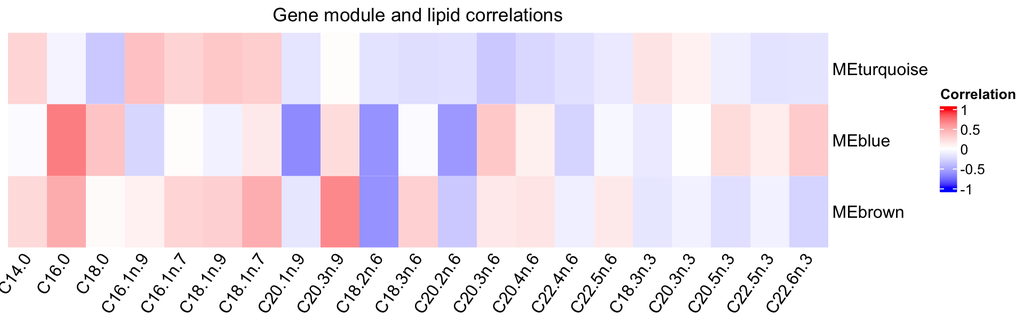

```r
Heatmap(
  eigengene_lipid_cor,
  name = "Correlation",
  col = colorRamp2(c(-1, 0, 1), c("blue", "white", "red"), space = "RGB"),
  cluster_rows = FALSE,
  cluster_columns = FALSE,
  column_names_rot = 55,
  column_title = "Gene module and lipid correlations"
)
```

And there we have it! We have successfully performed horizontal multi-omics integration. We identified groups of genes with similar expression patterns (modules), summarized each module with an eigengene, and examined how those modules correlate with lipid measurements across the same mice. We can now see which groups of genes are associated with which lipids!

## What biology does the blue module suggest?

Let us pull the blue genes from our module assignments and look up their mouse gene symbols. We prepared `nutrimouse_mouse_gene_mapping.tsv` using NCBI Gene and the original study’s probe annotations where available. The first column has the labels in Nutrimouse, and the second has the corresponding gene symbols. Read this table from `data/`, then use `match()` as we did on Day 1 to attach symbols to the genes in the blue module. Labels missing from the lookup will give `NA`. NCBI Gene https://www.ncbi.nlm.nih.gov/datasets/docs/v2/data-processing/gene-processing/geneftp/ and original study https://doi.org/10.1002/hep.21510.

```r
mouse_gene_map = read.delim(here("data", "nutrimouse_mouse_gene_mapping.tsv"))
head(mouse_gene_map)
```

```
##   array_label mouse_symbol
## 1       X36b4        Rplp0
## 2        ACBP          Dbi
## 3        ACC1        Acaca
## 4        ACC2        Acacb
## 5       ACOTH        Acot1
## 6       ADSS1        Adss1
```

```r
blue_module = subset(module_membership, module == "blue")
blue_module$mouse_symbol = mouse_gene_map$mouse_symbol[
  match(blue_module$gene, mouse_gene_map$array_label)]
head(blue_module)
```

```
##        gene module mouse_symbol
## ACBP   ACBP   blue          Dbi
## ALDH3 ALDH3   blue      Aldh3a1
## AOX     AOX   blue        Acox1
## BACT   BACT   blue         Actb
## BIEN   BIEN   blue       Ehhadh
## BSEP   BSEP   blue       Abcb11
```

```r
blue_symbols = unique(na.omit(blue_module$mouse_symbol))
length(blue_symbols)
```

```
## [1] 27
```

Let us send the blue module’s gene symbols to Enrichr and ask which mouse KEGG pathways they overlap with. `enrichr()` returns a list of results tables, so we select the `KEGG_2019_Mouse` table and store it as `blue_kegg`.

```r
library(enrichR)
enrichment = enrichr(blue_symbols, "KEGG_2019_Mouse")
```

```
## Uploading data to Enrichr... Done.
##   Querying KEGG_2019_Mouse... Done.
## Parsing results... Done.
```

```r
blue_kegg = enrichment[["KEGG_2019_Mouse"]]
```

```r
head(blue_kegg[, c("Term", "Overlap", "Adjusted.P.value")], 5)
```

```
##                                         Term Overlap Adjusted.P.value
## 1                     Fatty acid degradation    9/50     2.828925e-16
## 2                     PPAR signaling pathway   10/85     2.828925e-16
## 3                                 Peroxisome    6/84     2.693128e-08
## 4 Valine, leucine and isoleucine degradation    5/56     1.766240e-07
## 5                       Butanoate metabolism    3/27     7.883856e-05
```

```r
blue_kegg$Genes[1]
```

```
## [1] "HADHB;HADHA;CPT2;ACOX1;CYP4A10;EHHADH;ECI2;CYP4A14;ACAA1A"
```

## Questions

1. How many genes are in the blue module? How many are grey? Use `subset()` to list the genes in the turquoise module.
2. Look across the three boxplots. Which eigengene shows the clearest separation between genotypes? At what step did we use the genotype labels?
3. Look at the module heatmap. Each row is a gene, each column is a mouse, and blue and red show lower and higher expression for that gene. Use the genotype strip to find a block of blue-module genes with a similar pattern across genotypes. Do all the genes in that module follow the pattern equally closely? What do you notice when you look at the diet strip?
4. Use `subset()` on `meta` to get WT and PPAR-alpha-deficient mice on the fish-oil diet (`fish`). Select their `MEblue` scores, make a boxplot, and use `t.test()` to compare them. Is the difference significant at 0.05 within this diet?
5. Which module-lipid pairs have the strongest positive and negative correlations? Look up their values in `eigengene_lipid_cor`.
6. Make a copy of `eigengene_lipid` called `eigengene_linoleic`. Add `lipid_samples[, "C18.2n.6"]` as a `linoleic_acid` column. Adapt the scatterplot and the best-fit line to use this lipid. Try adding the diet shapes with `pch = sample_diet_shapes`.
7. Calculate the palmitic acid correlation again using just the WT mice. How does it compare with the correlation across all mice?
8. Look at the pathway results table, `blue_kegg`. Which two pathways tie for the smallest adjusted p-value? What do the two numbers in `9/50` count for fatty acid degradation?
9. Find the PPAR signaling row in the pathway results table, `blue_kegg`. Which genes does it share with the fatty acid degradation row? Use the `Genes` column to check. WGCNA used expression patterns to group the genes. How do these pathways help us describe the blue module, and how do they relate to the PPAR-alpha deficiency in these mice?
10. For further practice, work through the WGCNA mouse liver tutorial. It includes example data, R scripts, and PDFs showing the diagnostic plots, gene dendrograms, and module assignments. Use it to practice checking preprocessing, sample quality, and network settings for another dataset. https://edo98811.github.io/WGCNA_official_documentation/

# Vertical integration: find sample groups with SNF

## Learn patterns across both datasets

So far, we have used WGCNA to identify groups of genes with similar expression patterns and examined how those groups correlate with fatty-acid measurements. Now we want to answer a different question: can we combine gene expression and lipid measurements to identify groups of mice with similar molecular profiles? To do this, we will use a method called Similarity Network Fusion (SNF).

The basic idea is to determine which mice are most similar to each other based on their measurements. We start by calculating the distances between mice using their gene expression profiles, then repeat the process using their lipid profiles. Mice with similar measurements will have smaller distances, while mice with very different measurements will have larger distances. We then convert these distances into similarity networks, where mice with similar profiles have stronger connections. SNF combines the two networks into a single network that captures information from both datasets. We can use this combined network to cluster the mice and see how the resulting groups relate to genotype and diet.

Remember that in WGCNA, each node in our network represented a gene, and we used correlations to identify groups of genes. In SNF, each node represents a mouse, and we use similarities between mice to identify groups of samples. Since we are combining two datasets, we also need to make sure that the same mouse appears in the same row of both tables.

## Prepare the SNF input

We will use the 40 most variable genes and all 21 fatty acids. To identify the most variable genes, we calculate the standard deviation of each gene across the 40 mice and select the 40 with the highest values. Note that we are not using genotype or diet to select these genes, just how much their expression varies across samples. This keeps the example manageable while retaining genes that show substantial variation between mice.

Before calculating distances, we also need to standardize our measurements. Remember that Euclidean distance combines differences across all features, so genes or lipids with larger numerical variation could have a greater influence on the results. We use R’s scale() function to give each gene and fatty acid a mean of zero and a standard deviation of one across mice, just as we did earlier with PCA.

```r
gene_sd = apply(gene_samples, 2, sd)
selected_genes = head(names(sort(gene_sd, decreasing = TRUE)), 40)

# Center and scale the features within each table.
genes_snf = scale(gene_samples[, selected_genes])
lipids_snf = scale(lipid_samples)

dim(genes_snf)
```

```
## [1] 40 40
```

```r
dim(lipids_snf)
```

```
## [1] 40 21
```

```r
all(rownames(genes_snf) == meta$sample_id)
```

```
## [1] TRUE
```

```r
all(rownames(lipids_snf) == meta$sample_id)
```

```
## [1] TRUE
```

Our gene table now has 40 rows (mice) and 40 columns (genes), while the lipid table has the same 40 mice and 21 fatty acids. The two TRUE results confirm that the samples are in the same order as our metadata. Importantly, we have scaled each dataset separately because we will calculate distances between mice within each dataset before combining the resulting similarity networks.

## Compare mice within each dataset

Now we want to determine which mice have similar molecular profiles. We will start by calculating Euclidean distances between every pair of mice, separately for the gene and lipid datasets. Euclidean distance is the straight-line distance between two points, but it can also be calculated across many dimensions. For each pair of mice, we calculate the differences across all 40 genes (or 21 lipids), square those differences, add them together, and take the square root. Mice with similar profiles will have smaller distances, while mice with different profiles will have larger distances. SNFtool’s `dist2()` returns squared distances, so `sqrt()` completes the calculation:

```r
gene_distance = sqrt(dist2(genes_snf, genes_snf))
lipid_distance = sqrt(dist2(lipids_snf, lipids_snf))

dim(gene_distance)
```

```
## [1] 40 40
```

```r
round(gene_distance[1:3, 1:3], 2)
```

```
##         Mouse_1 Mouse_2 Mouse_3
## Mouse_1    0.00    4.15    6.80
## Mouse_2    4.15    0.00    5.23
## Mouse_3    6.80    5.23    0.00
```

```r
round(lipid_distance[1:3, 1:3], 2)
```

```
##         Mouse_1 Mouse_2 Mouse_3
## Mouse_1    0.00    7.16    6.85
## Mouse_2    7.16    0.00    1.05
## Mouse_3    6.85    1.05    0.00
```

We now have two distance matrices, one for genes and one for lipids. In each matrix, both the rows and columns represent mice, so each value tells us how far apart two mice are based on their measurements. Notice that the diagonal is zero because each mouse has a distance of zero from itself. Compare the same pair of mice in the two matrices. Their distances may differ depending on if we are looking at gene expression or lipid measurements.

Next, we need to turn these distances into similarities. SNFtool uses affinityMatrix() to do this, giving stronger connections to mice with similar molecular profiles and weaker connections to mice that are more different. When calculating these connection strengths, it also considers how close each mouse is to its nearest neighbors, accounting for differences in how tightly grouped the mice are.

We need to choose two settings: K determines how many nearby mice are used to calculate these similarities, while sigma controls how quickly the connection strengths decrease with distance. For this exercise, we will use K = 20 and sigma = 0.5, following the example provided in the SNFtool documentation. We apply these settings separately to the gene and lipid distances to create two similarity networks.

```r
snf_neighbors = 20
snf_sigma = 0.5

gene_similarity = affinityMatrix(gene_distance, K = snf_neighbors, sigma = snf_sigma)
lipid_similarity = affinityMatrix(lipid_distance, K = snf_neighbors, sigma = snf_sigma)

round(gene_similarity[1:3, 1:3], 3)
```

```
##         Mouse_1 Mouse_2 Mouse_3
## Mouse_1   0.183   0.048   0.015
## Mouse_2   0.048   0.190   0.030
## Mouse_3   0.015   0.030   0.178
```

```r
round(lipid_similarity[1:3, 1:3], 3)
```

```
##         Mouse_1 Mouse_2 Mouse_3
## Mouse_1   0.273   0.004   0.004
## Mouse_2   0.004   0.258   0.198
## Mouse_3   0.004   0.198   0.287
```

We now have two similarity matrices, again with 40 rows and 40 columns. Notice that unlike our distance matrices, where smaller values indicated greater similarity, larger values now indicate stronger connections between mice. Look at Mouse_2 and Mouse_3 again. In the gene network, Mouse_2 has a stronger connection to Mouse_1, while in the lipid network it has a stronger connection to Mouse_3. This shows why combining the datasets might be useful: mice that look similar based on gene expression may not be the same mice that look similar based on their lipids.

## Fuse the networks

Now that we have our two similarity networks, we can combine them using the SNF() function. Rather than simply averaging the two matrices, SNF allows the networks to exchange information about which mice are similar to one another. It considers not only the connection between two mice, but also their connections to other nearby mice. Over several rounds, the gene network is updated using information from the lipid network, and vice versa.

We will use the same neighborhood size (K = 20) and run 20 rounds of updates, again following the SNFtool example. After these updates, SNF combines the networks into a single similarity matrix that we can use to cluster our mice.

```r
snf_iterations = 20

fused_similarity = SNF(list(gene_similarity, lipid_similarity),
                                K = snf_neighbors, t = snf_iterations)
dim(fused_similarity)
```

```
## [1] 40 40
```

```r
round(fused_similarity[1:3, 1:3], 3)
```

```
##         Mouse_1 Mouse_2 Mouse_3
## Mouse_1   0.500   0.019   0.014
## Mouse_2   0.019   0.500   0.038
## Mouse_3   0.014   0.038   0.500
```

```r
all(rownames(fused_similarity) == meta$sample_id)
```

```
## [1] TRUE
```

```r
all(colnames(fused_similarity) == meta$sample_id)
```

```
## [1] TRUE
```

We now have one 40 x 40 matrix representing the combined gene and lipid similarities between mice. Let’s make a heatmap to see what these relationships look like. Remember that in WGCNA, each square compared two genes. Here, each square compares two mice. Darker squares indicate stronger connections. We will hide the diagonal since each mouse is being compared with itself.

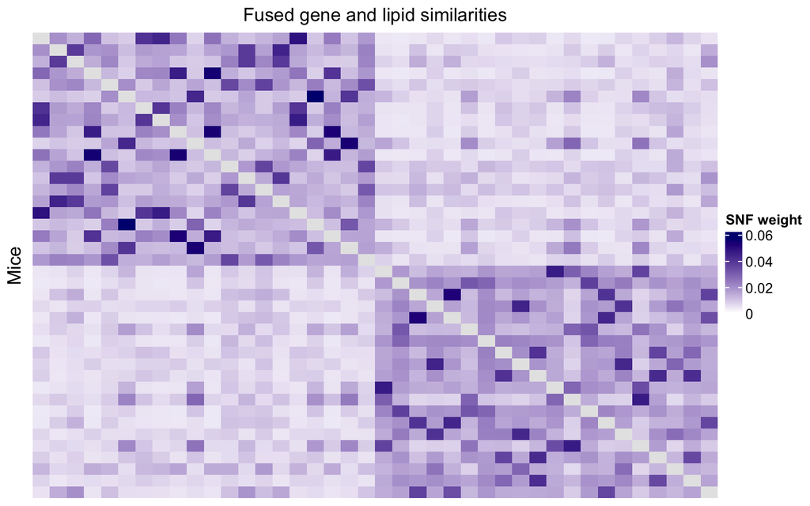

```r
fused_for_plot = fused_similarity
diag(fused_for_plot) = NA
Heatmap(
  fused_for_plot,
  name = "SNF weight",
  col = colorRamp2(c(0, max(fused_for_plot, na.rm = TRUE)), c("white", "navy")),
  na_col = "grey90",
  cluster_rows = FALSE, cluster_columns = FALSE,
  show_row_names = FALSE, show_column_names = FALSE,
  column_title = "Fused gene and lipid similarities",
  row_title = "Mice"
)
```

Notice the two darker blocks in the upper-left and lower-right corners of the heatmap. These show that mice within the first 20 samples and within the last 20 samples tend to be more similar to one another than to mice in the other group. This suggests that our combined gene and lipid data may contain two major groups of mice. There are also differences in shading within these blocks, suggesting there could be smaller groups as well. Remember that we have not clustered the samples yet. The mice are still in their original order, and the grey diagonal just marks where each mouse would be compared with itself.

## Estimate the number of clusters

Now that we have our fused similarity network, how do we decide how many clusters to identify? SNFtool has a function called estimateNumberOfClustersGivenGraph() that can help us with this. We will ask it to evaluate solutions with two through five clusters.

The function uses two methods called eigen-gap and rotation cost. Both examine patterns in the connections between mice, but they use different approaches to recommend a number of clusters. Eigen-gap looks for a large break in the network’s eigenvalues, which can indicate how many major groups are present. Rotation cost evaluates how clearly the mice can be separated into different groups. We do not need to get into the mathematics here, but it is important to understand that the two methods can recommend different numbers of clusters.

```r
set.seed(workshop_seed)
cluster_estimates = estimateNumberOfClustersGivenGraph(fused_similarity, NUMC = 2:5)
cluster_recommendations = data.frame(
  method = c("Eigen-gap", "Rotation cost"),
  clusters = c(cluster_estimates[["Eigen-gap best"]], cluster_estimates[["Rotation cost best"]])
)
cluster_recommendations
```

```
##          method clusters
## 1     Eigen-gap        2
## 2 Rotation cost        4
```

Interesting! Eigen-gap recommends two clusters, while rotation cost recommends four. This does not necessarily mean one method is right and the other is wrong. The two-cluster solution may capture the largest differences between mice, while four clusters may reveal additional patterns. Let’s try both and see how they relate to our experimental groups.

## Cluster the mice

Now we can actually assign mice to clusters using spectralClustering(). We give the function our fused similarity network and the number of clusters we want, and it returns a cluster assignment for each mouse. Let’s start with the two clusters recommended by eigen-gap and compare them with genotype using table().

```r
set.seed(workshop_seed)
eigen_gap_clusters = spectralClustering(
  fused_similarity, K = cluster_estimates[["Eigen-gap best"]]
)
names(eigen_gap_clusters) = rownames(fused_similarity)
table(cluster = eigen_gap_clusters[meta$sample_id], genotype = meta$genotype)
```

```
##        genotype
## cluster ppar wt
##       1    0 20
##       2   20  0
```

Look at that! Our two clusters correspond exactly to genotype. All 20 wild-type mice are in one cluster, and all 20 PPAR-alpha-deficient mice are in the other. Remember, we did not use genotype information to build the network or cluster the mice. SNF identified these groups using only the gene expression and lipid measurements. This suggests that genotype is a major source of variation in our combined dataset.

But what about the four clusters suggested by rotation cost? Could there be additional patterns in the data beyond genotype? Let’s repeat the clustering with four groups and see what we find.

```r
n_clusters = cluster_estimates[["Rotation cost best"]]
set.seed(workshop_seed)
sample_clusters = spectralClustering(fused_similarity, K = n_clusters)
names(sample_clusters) = rownames(fused_similarity)

all(names(sample_clusters) == meta$sample_id)
```

```
## [1] TRUE
```

```r
meta$cluster = sample_clusters[meta$sample_id]
cluster_colors = c("1" = "darkgreen", "2" = "goldenrod", "3" = "deeppink3",
                   "4" = "mediumpurple3", "5" = "sienna3")
cluster_colors = cluster_colors[as.character(sort(unique(meta$cluster)))]
meta$cluster_color = cluster_colors[as.character(meta$cluster)]
head(meta[, c("sample_id", "genotype", "diet", "cluster", "cluster_color")])
```

```
##   sample_id genotype diet cluster cluster_color
## 1   Mouse_1       wt  lin       4 mediumpurple3
## 2   Mouse_2       wt  sun       1     darkgreen
## 3   Mouse_3       wt  sun       1     darkgreen
## 4   Mouse_4       wt fish       4 mediumpurple3
## 5   Mouse_5       wt  ref       1     darkgreen
## 6   Mouse_6       wt  coc       2     goldenrod
```

```r
table(meta$cluster)
```

```
##
##  1  2  3  4
##  9  9 14  8
```

We now have four clusters containing 9, 9, 14, and 8 mice. The cluster numbers are just labels assigned by the algorithm and do not indicate any particular order or importance. We have also added these assignments to our metadata so we can compare them with genotype and diet. First, let’s see how the four-cluster solution compares with the two-cluster solution.

```r
table(eigen_gap = eigen_gap_clusters[meta$sample_id], rotation_cost = meta$cluster)
```

```
##          rotation_cost
## eigen_gap  1  2  3  4
##         1  8  4  0  8
##         2  1  5 14  0
```

This table shows how the mice from our original two clusters are distributed across the four new clusters. Each cell counts the number of mice assigned to that combination of groups. Notice that some of the four-cluster groups contain mice from both original clusters. In other words, the four-cluster solution is not simply dividing each genotype group into two smaller groups. It is finding a different grouping of mice based on their combined gene and lipid profiles. Next, let’s compare these groups with genotype and diet to see what might be driving these differences.

## What do the clusters represent?

We can use `table()` to compare the new cluster assignments with our metadata. We are using genotype and diet here to interpret the groups.

```r
table(cluster = meta$cluster, genotype = meta$genotype)
```

```
##        genotype
## cluster ppar wt
##       1    1  8
##       2    5  4
##       3   14  0
##       4    0  8
```

```r
table(cluster = meta$cluster, diet = meta$diet)
```

```
##        diet
## cluster coc fish lin ref sun
##       1   0    0   0   4   5
##       2   8    0   0   1   0
##       3   0    4   4   3   3
##       4   0    4   4   0   0
```

Clusters 3 and 4 are each made up of a single genotype, while clusters 1 and 2 contain a mix. All eight coconut-diet mice are in cluster 2. The sunflower-diet mice are split between clusters 1 and 3. We used the genotype and diet labels to describe these groups after clustering.

## Visualize the clusters

We will use PCA to show each mouse’s fused similarity profile on two axes. Both panels show the same mice, colored by cluster on the left and by genotype on the right. The shapes show diet, as in the morning PCA. The cluster assignments came from the full fused network.

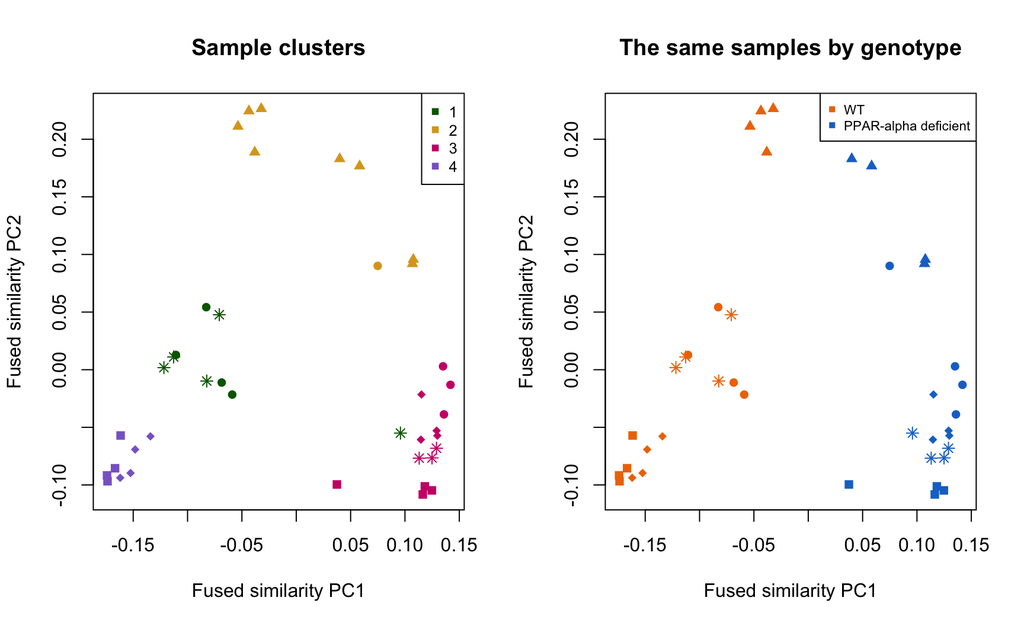

```r
similarity_pca = prcomp(fused_similarity, center = TRUE, scale. = FALSE)

# Save the current layout before changing the number of plot panels.
plot_settings = par("mfrow")
par(mfrow = c(1, 2))
plot(similarity_pca$x[, 1], similarity_pca$x[, 2],
     col = meta$cluster_color, pch = sample_diet_shapes,
     xlab = "Fused similarity PC1", ylab = "Fused similarity PC2", main = "Sample clusters")
legend("topright", legend = names(cluster_colors), col = cluster_colors, pch = 15, cex = 0.8)
plot(similarity_pca$x[, 1], similarity_pca$x[, 2],
     col = meta$color, pch = sample_diet_shapes,
     xlab = "Fused similarity PC1", ylab = "Fused similarity PC2", main = "The same samples by genotype")
legend("topright", legend = genotype_labels,
       col = genotype_colors, pch = 15, cex = 0.7)
```

```r
# Restore the layout we saved before making these plots.
par(mfrow = plot_settings)
```

## Questions

1. Use `table(meta$cluster)` to count the mice in each of the four clusters. Which is largest and which is smallest? Do the counts add up to 40?
2. Look at the cluster-by-genotype table. Which clusters contain only one genotype, and which contain both?
3. Look at the cluster-by-diet table. Which cluster contains all the coconut-diet mice? How are the fish-oil and linseed mice divided between clusters? Use the genotype table to help describe that split.
4. Compare the two PCA panels. Find clusters 3 and 4 in the left panel, then use the right panel and the diet shapes to describe those mice. Does this agree with the tables?

# Look at differences between the clusters

## Choose two clusters to compare

Yesterday we compared two experimental groups. We can use the same metadata-based selection to describe two of our new clusters. Let us compare cluster 3 (PPAR-alpha deficient) with cluster 4 (WT). Each includes four mice on the fish-oil diet and four on the linseed diet. Cluster 3 also includes three mice each on the reference and sunflower diets. Keep both genotype and diet in mind when you compare these clusters.

```r
group1 = 3
group2 = 4
group1_samples = subset(meta, cluster == group1)$sample_id
group2_samples = subset(meta, cluster == group2)$sample_id
length(group1_samples)
```

```
## [1] 14
```

```r
length(group2_samples)
```

```
## [1] 8
```

## Compare observed gene measurements

Remember our first comparison on Day 1. Start with the boxplot, then use Welch’s two-sample t-test to compare the group means. Let’s start with PMDCI as an example and compare its expression between clusters 3 and 4.

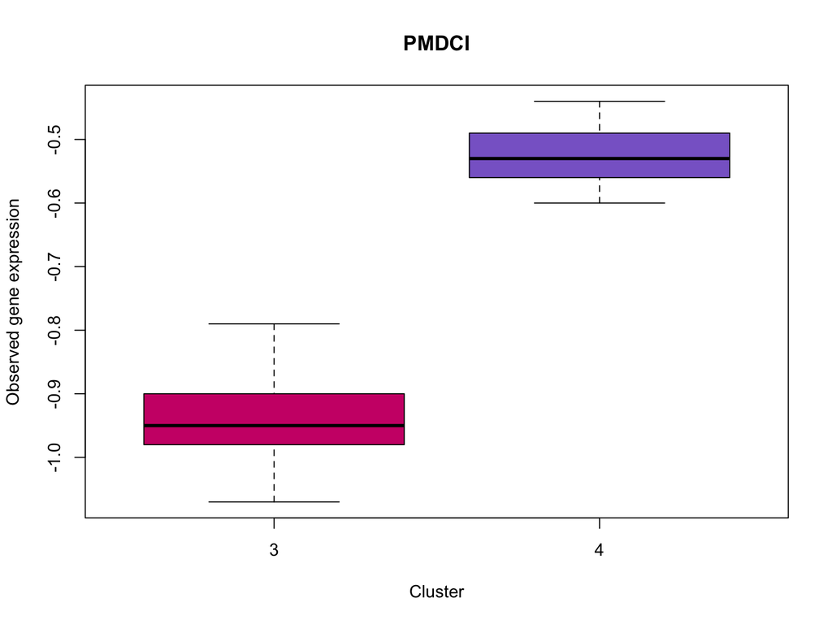

```r
example_gene = "PMDCI"
gene_group1 = gene_samples[group1_samples, example_gene]
gene_group2 = gene_samples[group2_samples, example_gene]

boxplot(gene_group1, gene_group2, names = c(group1, group2),
        col = cluster_colors[as.character(c(group1, group2))],
        xlab = "Cluster", ylab = "Observed gene expression",
        main = example_gene)
```

```r
example_test = t.test(gene_group2, gene_group1)
example_test
```

```
##
##  Welch Two Sample t-test
##
## data:  gene_group2 and gene_group1
## t = 15.69, df = 18.159, p-value = 5.247e-12
## alternative hypothesis: true difference in means is not equal to 0
## 95 percent confidence interval:
##  0.3625606 0.4745822
## sample estimates:
##  mean of x  mean of y
## -0.5250000 -0.9435714
```

```r
example_test$p.value
```

```
## [1] 5.246607e-12
```

Now let us use `colMeans()` to calculate a mean for every gene column. Then we can repeat the t-test with `apply()`. Yesterday we used `1` to go across protein rows. Here we use `2` because the genes are in columns. As on Day 1, use the Benjamini-Hochberg adjustment for multiple comparisons. These same measurements helped form the clusters. We will use the p-values to rank the genes that help describe the groups.

Welch’s t-test needs at least two observations in each group. If too few values are left after we remove missing values, `t.test()` gives an error. `tryCatch()` puts an `NA` in the p-value column for that gene and lets us continue to the next one.

```r
gene_differences = data.frame(
  gene = colnames(gene_samples),
  group1_mean = colMeans(gene_samples[group1_samples, ], na.rm = TRUE),
  group2_mean = colMeans(gene_samples[group2_samples, ], na.rm = TRUE)
)
gene_differences$difference = gene_differences$group2_mean - gene_differences$group1_mean

# Run one Welch t-test per gene and add its p-value before sorting the table.
gene_differences$pval = apply(gene_samples, 2, function(x) {
  x1 = x[group1_samples]
  x2 = x[group2_samples]
  x1 = x1[is.finite(x1)]
  x2 = x2[is.finite(x2)]
  # Record NA if t.test() gives an error.
  tryCatch(t.test(x2, x1)$p.value, error = function(e) NA_real_)
})
gene_differences$padj = p.adjust(gene_differences$pval, method = "BH")

gene_differences = subset(gene_differences, is.finite(difference))
gene_differences = gene_differences[order(gene_differences$padj, gene_differences$pval), ]
head(gene_differences, 10)
```

```
##              gene group1_mean group2_mean difference         pval         padj
## PMDCI       PMDCI  -0.9435714    -0.52500  0.4185714 5.246607e-12 6.295929e-10
## THIOL       THIOL  -0.6328571    -0.16875  0.4641071 1.974478e-10 1.184687e-08
## ALDH3       ALDH3  -0.9121429    -0.70750  0.2046429 1.145412e-08 4.581646e-07
## CYP3A11   CYP3A11  -0.6578571    -0.11250  0.5453571 2.867623e-08 8.602868e-07
## L.FABP     L.FABP  -0.1628571     0.20250  0.3653571 1.611855e-07 3.868453e-06
## mHMGCoAS mHMGCoAS  -0.3350000    -0.05500  0.2800000 6.136278e-07 1.227256e-05
## AOX           AOX  -0.3500000    -0.11875  0.2312500 1.052121e-06 1.631174e-05
## CYP4A10   CYP4A10  -1.1571429    -0.64000  0.5171429 1.087449e-06 1.631174e-05
## HPNCL       HPNCL  -0.7857143    -0.60250  0.1832143 9.335756e-06 1.244767e-04
## CPT2         CPT2  -1.0364286    -0.87625  0.1601786 1.144845e-05 1.373814e-04
```

```r
subset(gene_differences, gene == example_gene)
```

```
##        gene group1_mean group2_mean difference         pval         padj
## PMDCI PMDCI  -0.9435714      -0.525  0.4185714 5.246607e-12 6.295929e-10
```

Check that the `PMDCI` row gives the same means and raw p-value as the one-gene calculation. A positive difference means a higher observed mean in `group2`. The smallest adjusted p-values are at the top, with the raw p-value breaking ties. Let us plot the first gene in that table and show its values for all four clusters. `split()` gives `boxplot()` a group of values for each cluster.

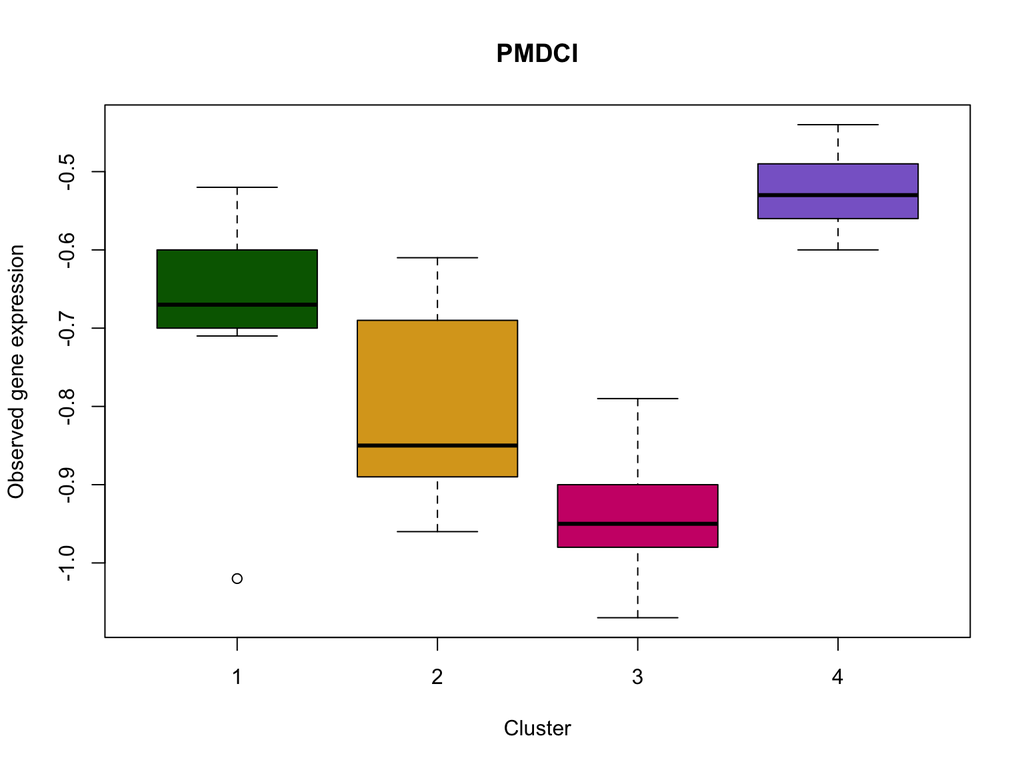

```r
gene_to_plot = gene_differences$gene[1]
boxplot(split(gene_samples[, gene_to_plot], meta$cluster),
        col = cluster_colors,
        xlab = "Cluster", ylab = "Observed gene expression",
        main = gene_to_plot)
```

The boxplot shows whether the group difference describes most mice or is driven by a few observations. Look back at the genotype and diet tables as you interpret it.

## Gene cluster volcano plot

Let us use the Day 1 volcano plot to look at all the genes at once. Each point is one gene. The x-axis is the difference between the observed means (`group2 - group1`) on the supplied expression scale. The y-axis is `-log10()` of the adjusted p-value, so smaller adjusted p-values appear higher. As on Day 1, we will use an adjusted p-value cutoff of 0.05. Color shows which cluster has the higher mean among genes that pass the cutoff.

```r
gene_fdr_cutoff = 0.05
gene_volcano = subset(gene_differences, is.finite(padj) & padj > 0)
gene_volcano$neglog10padj = -log10(gene_volcano$padj)
passes_fdr = gene_volcano$padj <= gene_fdr_cutoff
higher_in_group2 = passes_fdr & gene_volcano$difference > 0
higher_in_group1 = passes_fdr & gene_volcano$difference < 0
gene_volcano$color = "grey60"
gene_volcano$color[higher_in_group2] = "red"
gene_volcano$color[higher_in_group1] = "blue"

# The table is already sorted by adjusted p-value. Label up to two per direction.
gene_labels = rbind(head(gene_volcano[higher_in_group2, ], 2),
                    head(gene_volcano[higher_in_group1, ], 2))
gene_labels[, c("gene", "difference", "padj")]
```

```
##        gene  difference         padj
## PMDCI PMDCI  0.41857143 6.295929e-10
## THIOL THIOL  0.46410714 1.184687e-08
## CAR1   CAR1 -0.12089286 1.499903e-02
## Ntcp   Ntcp -0.08535714 3.950317e-02
```

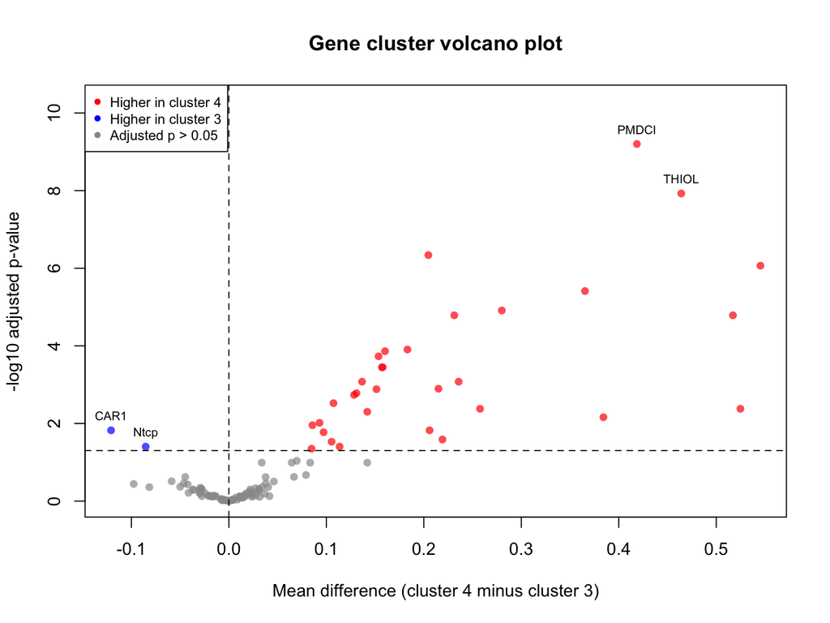

```r
plot(gene_volcano$difference, gene_volcano$neglog10padj,
     ylim = c(0, 1.12 * max(gene_volcano$neglog10padj, -log10(gene_fdr_cutoff))),
     col = adjustcolor(gene_volcano$color, alpha.f = 0.7), pch = 16,
     xlab = paste0("Mean difference (cluster ", group2, " minus cluster ", group1, ")"),
     ylab = "-log10 adjusted p-value", main = "Gene cluster volcano plot")
abline(v = 0, lty = 2)
abline(h = -log10(gene_fdr_cutoff), lty = 2)
text(gene_labels$difference, gene_labels$neglog10padj,
     labels = gene_labels$gene, pos = 3, cex = 0.7)
legend("topleft", legend = c(paste("Higher in cluster", c(group2, group1)),
                             paste("Adjusted p >", gene_fdr_cutoff)),
       col = c("red", "blue", "grey60"), pch = 16, cex = 0.8)
```

Find the gene we just boxplotted. Is it to the left or right of zero? Check that against its two means in the table.

## Compare observed lipids

We can use the same mean calculation with `lipid_samples`. Each mean is a percentage of the measured fatty acids. The difference is in percentage points.

```r
lipid_differences = data.frame(
  lipid = colnames(lipid_samples),
  group1_mean = colMeans(lipid_samples[group1_samples, ], na.rm = TRUE),
  group2_mean = colMeans(lipid_samples[group2_samples, ], na.rm = TRUE)
)
lipid_differences$difference = lipid_differences$group2_mean - lipid_differences$group1_mean
lipid_differences = subset(lipid_differences, is.finite(difference))
lipid_differences = lipid_differences[order(abs(lipid_differences$difference), decreasing = TRUE), ]
head(lipid_differences, 10)
```

```
##             lipid group1_mean group2_mean  difference
## C18.2n.6 C18.2n.6   22.908571    11.10750 -11.8010714
## C22.6n.3 C22.6n.3    5.573571    13.31250   7.7389286
## C16.0       C16.0   19.515714    26.71875   7.2030357
## C18.1n.9 C18.1n.9   25.359286    18.27000  -7.0892857
## C18.0       C18.0    5.367857     9.37750   4.0096429
## C20.5n.3 C20.5n.3    1.742143     5.65500   3.9128571
## C18.3n.3 C18.3n.3    6.009286     3.50875  -2.5005357
## C22.5n.3 C22.5n.3    1.028571     1.63375   0.6051786
## C18.1n.7 C18.1n.7    2.780714     2.17625  -0.6044643
## C16.1n.7 C16.1n.7    3.390714     2.94500  -0.4457143
```

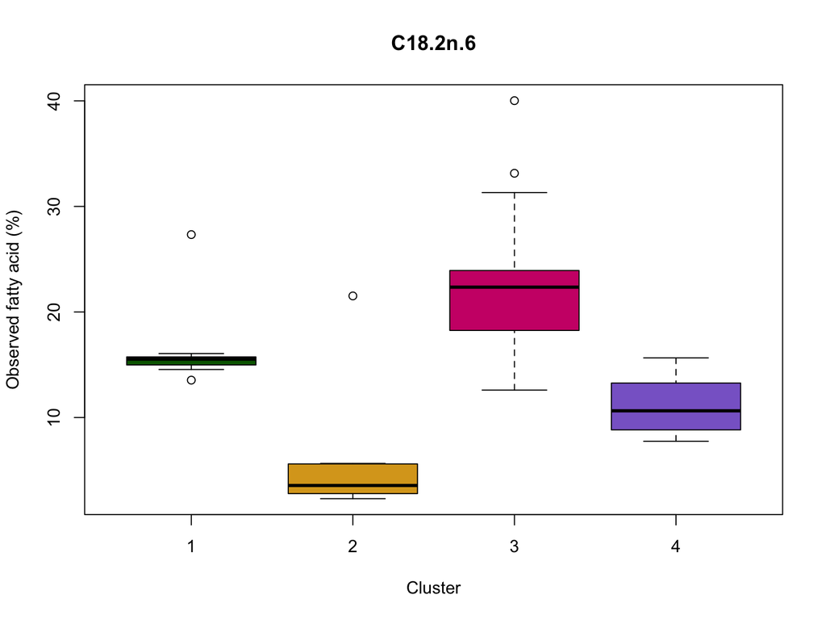

```r
lipid_to_plot = lipid_differences$lipid[1]
boxplot(split(lipid_samples[, lipid_to_plot], meta$cluster),
        col = cluster_colors,
        xlab = "Cluster", ylab = "Observed fatty acid (%)",
        main = lipid_to_plot)
```

## Optional plot: cluster the observed gene profiles

We can make a heatmap of the ten genes with the smallest adjusted p-values. Let us standardize each gene across the 40 mice. Blue means lower expression for that gene, white is near its average, and red means higher expression. The annotation above the heatmap uses the cluster colors from our metadata.

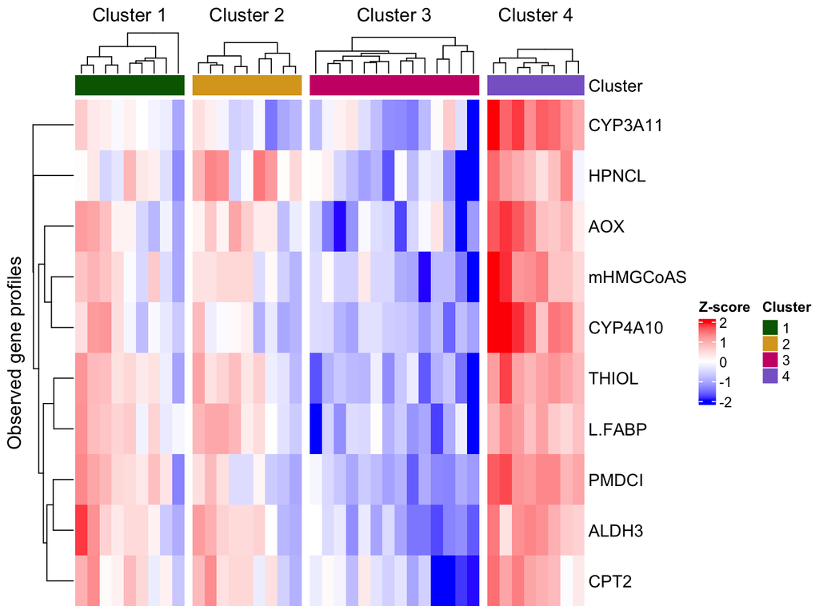

```r
plot_genes = head(gene_differences$gene, 10)
heatmap_values = scale(gene_samples[meta$sample_id, plot_genes])
heatmap_clusters = factor(meta$cluster, levels = names(cluster_colors))

column_annot = HeatmapAnnotation(
  Cluster = heatmap_clusters,
  col = list(Cluster = cluster_colors)
)

Heatmap(
  t(heatmap_values), # genes in rows, mice in columns
  name = "Z-score",
  col = colorRamp2(c(-2, 0, 2), c("blue", "white", "red"), space = "RGB"),
  top_annotation = column_annot,
  na_col = "grey80",
  show_column_names = FALSE,
  cluster_rows = TRUE,
  cluster_columns = TRUE,
  # Split by the existing clusters and cluster mice within each group.
  column_split = heatmap_clusters,
  cluster_column_slices = FALSE,
  column_gap = unit(2, "mm"),
  column_title = paste("Cluster", names(cluster_colors)),
  row_title = "Observed gene profiles"
)
```

Each block contains mice from one of the four clusters we already assigned. The small gaps separate those groups. Within each block, the column tree puts mice with similar expression patterns near each other. The row tree groups genes with similar patterns across the 40 mice.

We prepared two datasets, fused their similarity networks, and used the fused network to cluster the mice. We then returned to the metadata and observed measurements to describe those groups.

## Questions

1. Try comparing clusters 1 and 2. Which diets are most common in these two groups? Rerun the cluster comparison code for this pair. Do the largest differences involve the same genes and lipids?
2. Choose another gene from the results table and plot its values by cluster.
3. Find a gene with a large difference and a gene with a small adjusted p-value. How do their boxplots compare?

# Save the results

We will save the gene modules, the fused network, the cluster assignments and metadata, and the tables describing cluster differences. The sample_id column lets us match the results with other files later.

```r
module_scores = data.frame(sample_id = rownames(module_eigengenes), module_eigengenes)

write.table(module_membership, file.path(work_folder, "day2_gene_modules.tsv"),
            sep = "\t", quote = FALSE, row.names = FALSE)
write.table(module_scores, file.path(work_folder, "day2_module_summaries.tsv"),
            sep = "\t", quote = FALSE, row.names = FALSE)
write.table(eigengene_lipid_cor, file.path(work_folder, "day2_module_lipid_correlations.tsv"),
            sep = "\t", quote = FALSE, col.names = NA)
write.table(meta, file.path(work_folder, "day2_sample_clusters.tsv"),
            sep = "\t", quote = FALSE, row.names = FALSE)
write.table(gene_differences, file.path(work_folder, "day2_cluster_gene_differences.tsv"),
            sep = "\t", quote = FALSE, row.names = FALSE)
write.table(lipid_differences, file.path(work_folder, "day2_cluster_lipid_differences.tsv"),
            sep = "\t", quote = FALSE, row.names = FALSE)
saveRDS(gene_network, file.path(work_folder, "day2_wgcna_fit.rds"))
saveRDS(list(gene_similarity = gene_similarity, lipid_similarity = lipid_similarity,
             fused_similarity = fused_similarity, cluster_estimates = cluster_estimates,
             sample_clusters = sample_clusters, eigen_gap_clusters = eigen_gap_clusters,
             selected_genes = selected_genes, metadata = meta,
             gene_observed = gene_samples, lipid_observed = lipid_samples),
        file.path(work_folder, "day2_snf_analysis.rds"))
writeLines(capture.output(sessionInfo()), file.path(work_folder, "day2_sessionInfo.txt"))
```

Let us read the cluster table back in, as if we were opening it in a new session. Check that it still has one row per mouse and that the IDs and cluster labels match `meta`.

```r
saved_clusters = read.delim(file.path(work_folder, "day2_sample_clusters.tsv"))
nrow(saved_clusters)
```

```
## [1] 40
```

```r
head(saved_clusters[, c("sample_id", "cluster")])
```

```
##   sample_id cluster
## 1   Mouse_1       4
## 2   Mouse_2       1
## 3   Mouse_3       1
## 4   Mouse_4       4
## 5   Mouse_5       1
## 6   Mouse_6       2
```

```r
identical(saved_clusters$sample_id, meta$sample_id)
```

```
## [1] TRUE
```

```r
all(saved_clusters$cluster == meta$cluster)
```

```
## [1] TRUE
```

We should see 40 rows and two `TRUE` results.

## Final exercise

Write a short interpretation using the figures and tables we made.

1. Describe one relationship between a gene module and a lipid from the horizontal analysis.
2. Explain what a weight in the fused network represents and how we used the network to cluster the mice.
3. Describe the sample clusters using both the experimental metadata and the observed gene/lipid profiles.
4. Name one limitation you would investigate before drawing a biological conclusion.

# Optional extensions

## Joint pathway demonstration in MetaboAnalyst

Joint Pathway Analysis is another example of horizontal integration. It takes a list of genes or proteins and a list of metabolites from the same biological comparison, maps them to known pathways, and tests for pathway enrichment. We will look for pathways supported by the protein/gene measurements, the metabolite measurements, and their combined evidence.

We will use the MetaboAnalyst web interface for this exercise. The Joint Pathway Analysis web tutorial is at https://drive.google.com/file/d/1HVoXNX98CZLcpr7MkpVZP5DueXcnZeIj/view. The tool is also described in section 2.8 at https://www.metaboanalyst.ca/docs/RTutorial.xhtml.

For this optional exercise, use the built-in human Proteins-Compounds example comparing severe and moderate COVID-19. It provides proteins identified by gene symbols and metabolites identified by HMDB IDs. Example datasets and input lists https://www.metaboanalyst.ca/faces/upload/PathUploadView.xhtml.

### Run the analysis in the browser

1. Open https://www.metaboanalyst.ca/, select Joint Pathway Analysis, choose Try our example, and select the human Proteins-Compounds COVID-19 example.
2. Confirm the organism is Homo sapiens. Inspect the gene symbols and metabolite HMDB IDs. Check for duplicate identifiers.
3. Inspect the mapping report. Which identifiers matched, and which were unmatched or ambiguous?
4. Run the pathway analysis. Compare protein/gene-only, metabolite-only, and integrated results using the corresponding options. Does a joint result have evidence from both layers, or mostly one?
5. Open one pathway and identify the proteins/genes and metabolites contributing to it. Look at the adjusted p-values as well as the pathway diagram.
6. Download the pathway results table, mapping report, and figures. Save the input lists, selected settings, background/universe, and database version or date. Also save the R command history if it is offered in the session’s download options.

The background describes the genes and compounds that could have contributed to the enrichment result. Check what background the tool uses. Enrichment does not by itself tell us whether a pathway is activated or inhibited.

### Bring the results into R

We can use the website for the analysis and then make our own figures from the downloaded results table. This uses the same table-reading and plotting skills we practiced on Day 1.

If the download is a ZIP file, extract it first and find the pathway results CSV. The following chunk has eval = FALSE because it needs the file you downloaded. Run it manually; file.choose() opens a dialog where you can select that CSV.

```r
pathway_results = read.csv(file.choose(), check.names = FALSE)
head(pathway_results)
names(pathway_results)
```

check.names = FALSE preserves the column labels in the downloaded table. Inspect them before selecting columns; different result tables can use different labels.

Use the pathway barplot from Day 1 as a starting point:

1. Find the pathway-name and adjusted p-value columns in your downloaded table.
2. Sort by adjusted p-value and select up to ten pathways.
3. Plot -log10 adjusted p-value as a horizontal barplot, with the pathway names beside the bars.
4. Add a line marking your chosen adjusted p-value cutoff. Keep pathways below that threshold distinct from terms shown only because they are among the top ten.

Changing the plot changes how we display the downloaded results. It does not rerun or change the enrichment calculation. Loading a CSV and plotting it in base R does not require MetaboAnalystR.

### Explore the saved R code later

MetaboAnalyst can record the R commands used for an analysis. The command history lets us inspect the steps and settings, and provides a starting point for repeating or adapting an analysis locally.

Those commands use MetaboAnalystR. Running them locally requires the package, its dependencies, and appropriate input file paths. Installation can take some troubleshooting because it includes several R/Bioconductor dependencies and system requirements. Official installation instructions https://github.com/xia-lab/MetaboAnalystR. Keep the command history with the input files and record the package and database versions if you try it.

### Questions

1. Which pathway has evidence from both the protein/gene list and the metabolite list? Identify at least one contributing feature from each.
2. Does the integrated result agree with the single-layer analyses? What might explain a difference?
3. What do the mapping report and background tell you about interpreting the result?
4. What would you change in the website’s figure to make it easier to read? Try making that change in R using the downloaded table.

## Mouse gene ID mapping with biomaRt

Earlier, we used a prepared table to convert the older Nutrimouse gene labels into mouse gene symbols. But what if we need to do this for our own data? The Bioconductor package biomaRt allows us to query the Ensembl database directly to retrieve gene identifiers and annotations. For example, we might want to convert gene symbols into Ensembl or Entrez Gene IDs, or look up other information about our genes.

Let’s try a simple example using three mouse genes. First, we need to install and load biomaRt, then connect to the Ensembl mouse gene database using useEnsembl(). The biomart = “genes” argument selects the gene annotation database, while dataset = “mmusculus_gene_ensembl” tells Ensembl that we are working with mouse genes. For human data, we would use “hsapiens_gene_ensembl” instead.

```r
BiocManager::install("biomaRt", ask = FALSE, update = FALSE)
library(biomaRt)
mouse_mart = useEnsembl(biomart = "genes", dataset = "mmusculus_gene_ensembl")
```

Now we can use getBM() to retrieve the gene annotations. We specify the identifiers we already have using filters and values, and the information we want back using attributes. Here, “mgi_symbol” tells Ensembl that our inputs are mouse gene symbols, and we provide three examples: Ppara, Acaca, and Fasn. We ask Ensembl to return their gene symbols, Ensembl gene IDs, and Entrez Gene IDs. Finally, mart = mouse_mart tells the function which database to query.

```r
mouse_mapping = getBM(
  attributes = c("mgi_symbol", "ensembl_gene_id", "entrezgene_id"),
  filters = "mgi_symbol", values = c("Ppara", "Acaca", "Fasn"),
  mart = mouse_mart
)
mouse_mapping
```

We now have a table mapping our three gene symbols to their corresponding identifiers! Notice that we included the original gene symbols in the output so we know which IDs belong to which genes. In practice, the results may not be returned in the same order as our inputs, and some genes may have multiple matches or no matches at all. We should always check the mappings before adding them back to our original dataset.

What if we want to look up something other than Ensembl or Entrez IDs? biomaRt provides functions to explore all the available options. listFilters() shows the types of identifiers and other criteria we can use as inputs, while listAttributes() shows the information we can retrieve. We can also use searchAttributes() to search for particular fields, such as UniProt identifiers.

```r
mapping_inputs = listFilters(mouse_mart)
mapping_outputs = listAttributes(mouse_mart)
head(mapping_inputs)
head(mapping_outputs)
searchAttributes(mouse_mart, pattern = "uniprot")
```

You can use View(mapping_inputs) or View(mapping_outputs) to browse the full tables in RStudio. The listDatasets() function also lets you explore the available organisms. This makes biomaRt useful for many different annotation tasks, including mapping between gene symbols, Ensembl IDs, Entrez IDs, and protein identifiers.

Keep in mind that biomaRt queries a live database, so you need an internet connection, and annotations may change between Ensembl releases. For reproducibility, it is good practice to save your mapping table and record which Ensembl release you used.

The biomaRt tutorial has more examples at https://bioconductor.org/packages/release/bioc/vignettes/biomaRt/inst/doc/accessing_ensembl.html.

## Further reading

- We published iModMix, a method similar to WGCNA that we designed for multi-omics, in Bioinformatics. Published paper https://doi.org/10.1093/bioinformatics/btag030.
- Try iModMix interactively with the example data at https://imodmix.moffitt.org/. The app runs on a slow virtual machine, so if you are really interested I recommend running it locally for your own analysis. We have an R package with installation instructions and a worked tutorial at https://bioconductor.org/packages/iModMix.
- The WGCNA tutorials cover choosing settings for a new dataset. https://edo98811.github.io/WGCNA_official_documentation/
- The SNFtool manual includes a worked example of building similarity networks, fusing them, and clustering the samples. https://cran.r-project.org/web/packages/SNFtool/SNFtool.pdf